# MB5370 Module 04. Data Science in R 1

## Overriding defaults in ggplot2

Make some new data

```r
demo <- tribble(
  ~cut,         ~freq,
  "Fair",       1610,
  "Good",       4906,
  "Very Good",  12082,
  "Premium",    13791,
  "Ideal",      21551
)
demo
```

```
## # A tibble: 5 × 2
##   cut        freq
##   <chr>     <dbl>
## 1 Fair       1610
## 2 Good       4906
## 3 Very Good 12082
## 4 Premium   13791
## 5 Ideal     21551
```

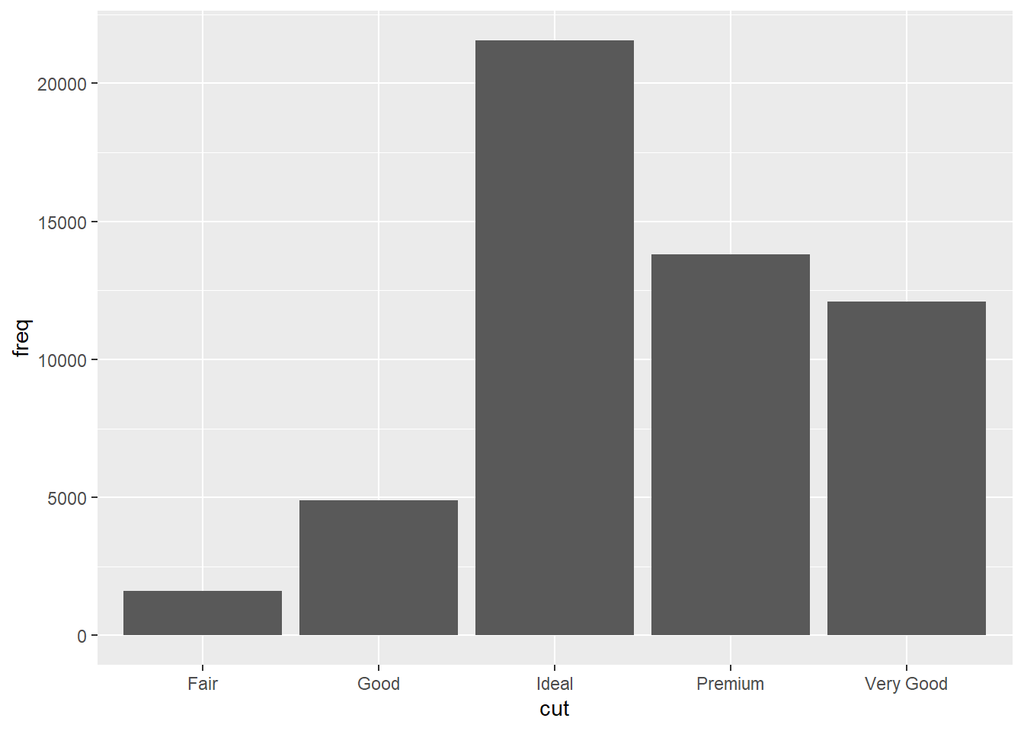

```r
ggplot(data = demo) +
  geom_bar(mapping = aes(x = cut, y = freq), stat = "identity")
```

### What if we want to know the proportion rather than the absolute frequency?

```
## Warning: `stat(prop)` was deprecated in ggplot2 3.4.0.
## ℹ Please use `after_stat(prop)` instead.
## This warning is displayed once every 8 hours.
## Call `lifecycle::last_lifecycle_warnings()` to see where this warning was
## generated.
```

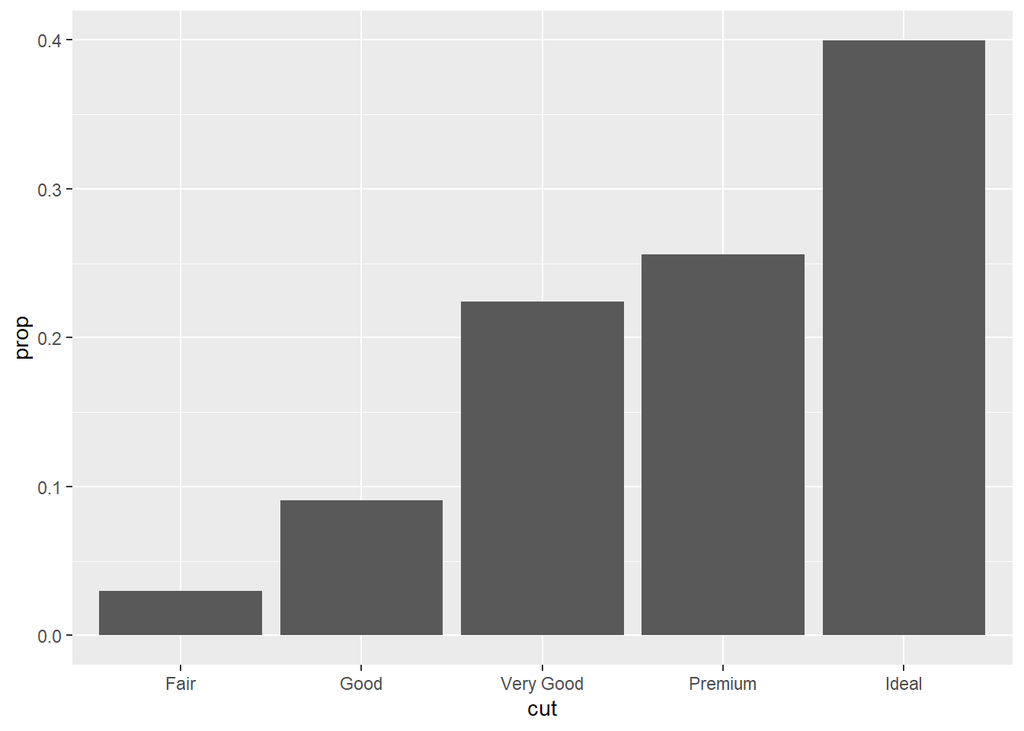

```r
ggplot(data = diamonds) +
  geom_bar(mapping = aes(x = cut, y = stat(prop), group = 1))
```

If you get the following: Warning: `stat(prop)` was deprecated in ggplot2 3.4.0. You can use # geom_bar(mapping = aes(x = cut, y = stage(after_stat = prop), group = 1))

### Plotting statistical details

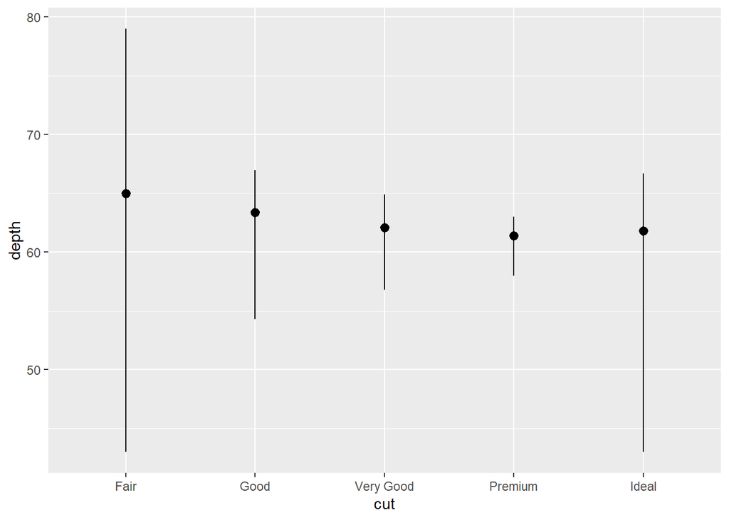

```r
ggplot(data = diamonds) +
  stat_summary(
    mapping = aes(x = cut, y = depth),
    fun.min = min,
    fun.max = max,
    fun = median
  )
```

## Aesthetic Adjustments

Another way to boost the way you can convey information with plots using ggplot2 is to use aesthetics like color or fill to change aspects of bar colours. We already did this once, but there are multiple options available to you, including changing the fill our outline colors.

### Adjustment 1

Has grey bars with a highlighted color around each bar

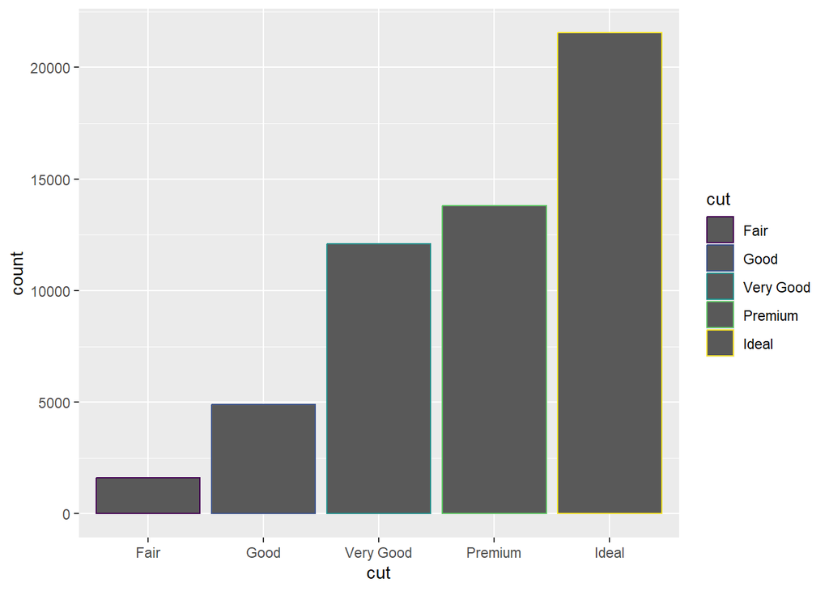

```r
ggplot(data = diamonds) +
  geom_bar(mapping = aes(x = cut, colour = cut))
```

### Adjustment 2

Changes the color for each bar

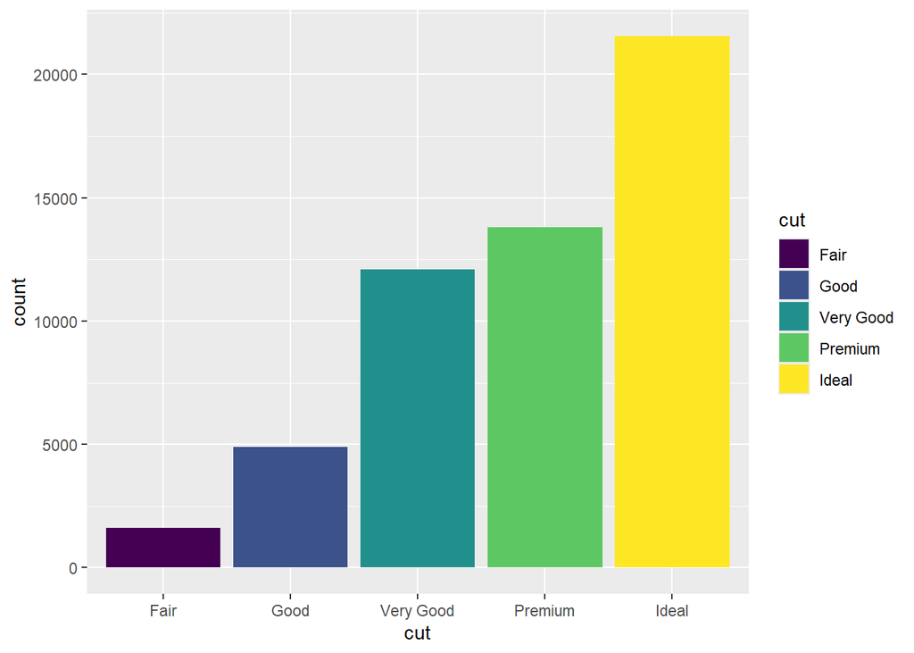

```r
ggplot(data = diamonds) +
  geom_bar(mapping = aes(x = cut, fill = cut))
```

Question: Does anyone notice anything different in the color scheme of this plot? (Hint: It’s in the viridis color palette (color blind friendly), but why is it different from the color palette we used earlier?) Check out the difference:

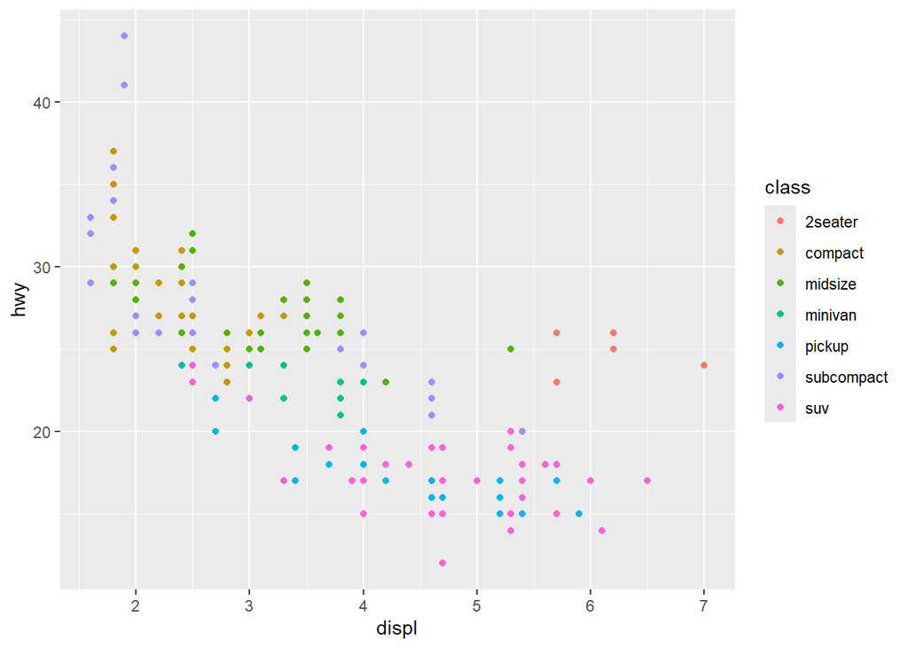

```r
ggplot(data = mpg, mapping = aes(x = displ, y = hwy)) +
  geom_point(mapping = aes(color = class))
```

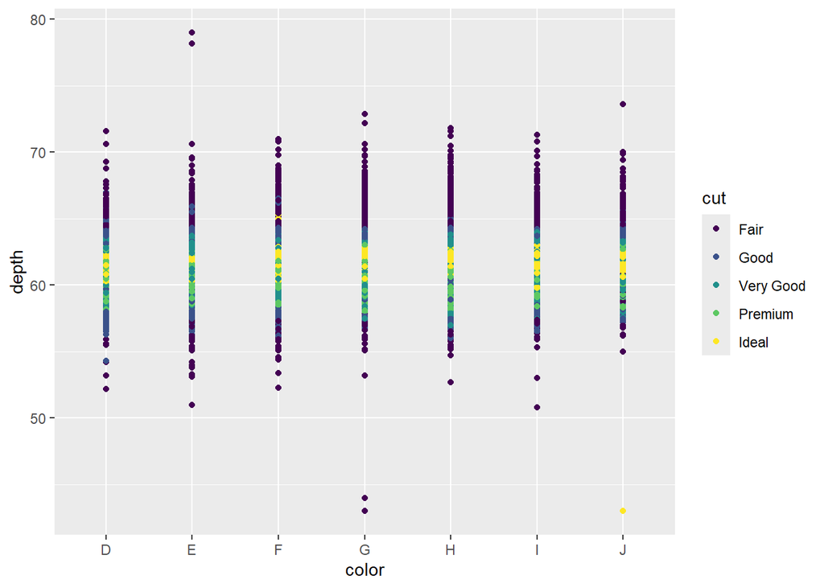

```r
ggplot(data = diamonds, mapping = aes(x = color, y = depth)) +
  geom_point(mapping = aes(color = cut))
```

### Filling by a variable

Now try using these aesthetics to color by another variable like clarity. Notice how the stacking is done automatically. This is done behind the scenes with a position argument.

Stacks the bars and has a different color for each clarity

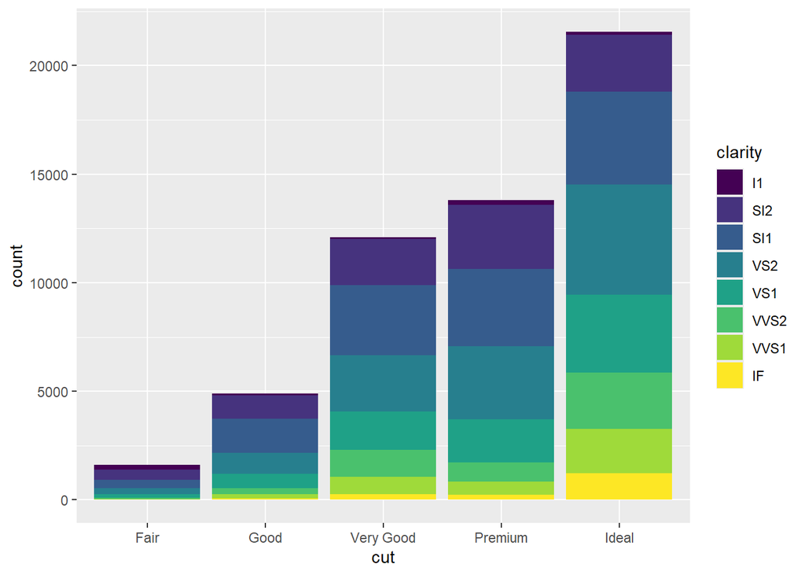

```r
ggplot(data = diamonds) +
  geom_bar(mapping = aes(x = cut, fill = clarity))
```

### To alter transparency (alpha)

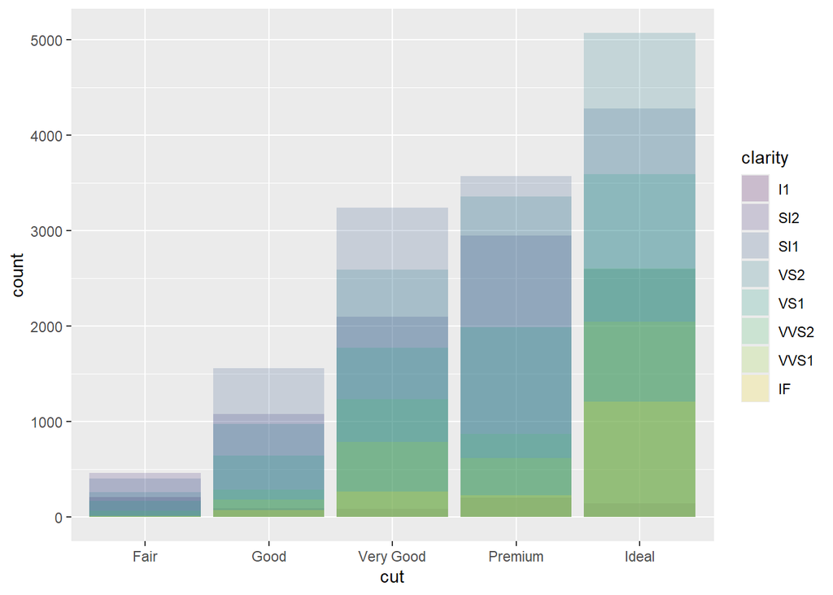

```r
ggplot(data = diamonds, mapping = aes(x = cut, fill = clarity)) +
  geom_bar(alpha = 1/5, position = "identity")
```

### To color the bar outlines with no fill color

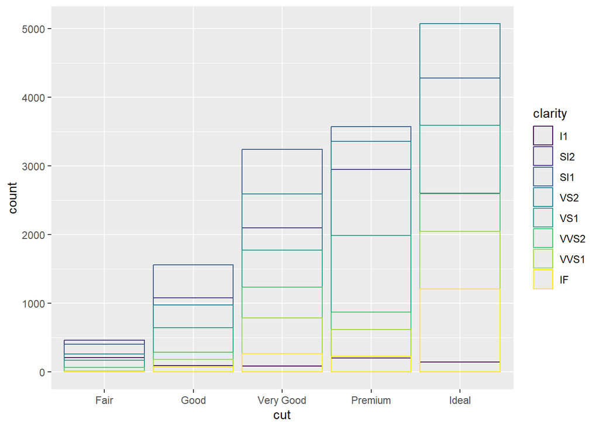

```r
ggplot(data = diamonds, mapping = aes(x = cut, colour = clarity)) +
  geom_bar(fill = NA, position = "identity")
```

### Position adjustments

position = “fill” works like stacking, but makes each set of stacked bars the same height.

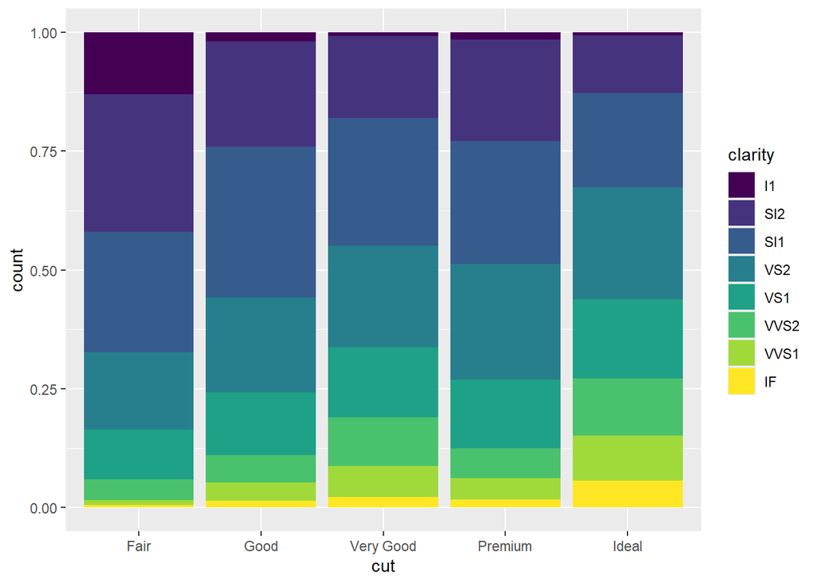

```r
ggplot(data = diamonds) +
  geom_bar(mapping = aes(x = cut, fill = clarity), position = "fill")
```

### position = “dodge”

Places overlapping objects directly beside one another.

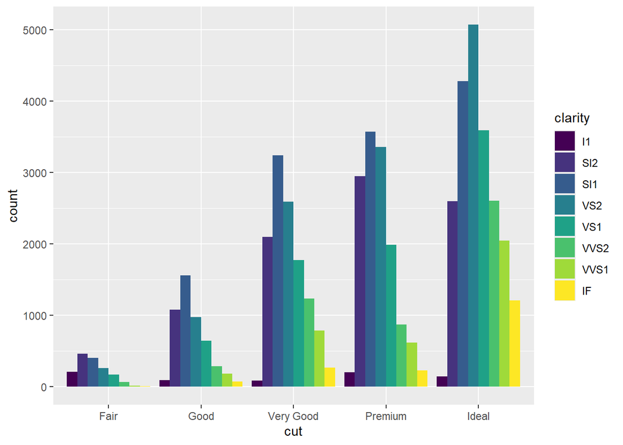

```r
ggplot(data = diamonds) +
  geom_bar(mapping = aes(x = cut, fill = clarity), position = "dodge")
```

### Jittering

position = “jitter” adds a small amount of random noise to each point to avoid overplotting when points overlap. This is useful for scatter plots but not bar plots.

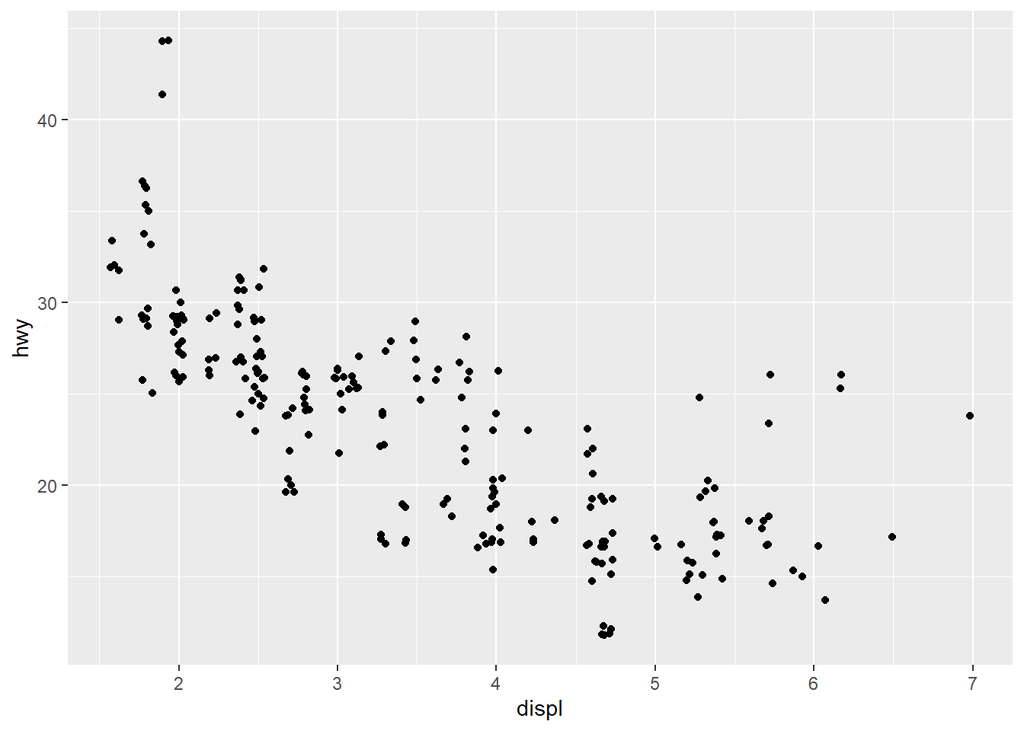

```r
ggplot(data = mpg) +
  geom_point(mapping = aes(x = displ, y = hwy), position = "jitter")
```